# NFL Losers Pool 2021 Optimal Pick Algorithm

Jordan Hutchings

08/11/2021

## The 2021 NFL Losers Pool

I’ve entered into an annual NFL Losers Pool with some friends. A Losers Pool is a fantasy NFL league where each competitor in the league is required to pick any team playing that week to lose their game. If the picked team wins, the player is eliminated from the pool. The players who correctly picked a losing team that week move on and must pick a new team to lose the following week. The last person remaining in the Losers Pool is crowned the champion.

Arguably, I may be the least informed competitor in the pool. Especially since I haven’t followed football since I lost out of the 2020 Losers Pool, however, I have a trick up my sleeve and plan on creating an optimization algorithm to outperform the others in the pool.

My strategy is to use game-by-game forecasts for the 2021 season, then optimize my picks maximizing the likelihood of reaching a given week. Hopefully, with enough foresight, data analytics, and some luck, I’ll be able to outlast my competitors.

While it would have been a great exercise to forecast the NFL games, I’ve instead choose to leverage the NFL game projections made by [FiveThirtyEight](https://projects.fivethirtyeight.com/2021-nfl-predictions/games/). These projections are based off their quarterback-adjusted ELO forecasts. Lets quickly review ELO ratings for those who are unfamiliar, or just need a touch-up on how we can leverage the probability of winning from the ratings.

## ELO Ratings

ELO is a fantastic and widely used method of ranking two competing teams. Commonly used in chess, your ELO score is a representation of your skill based on your performance against other ELO ranked players. There is a great video describing the ELO process made by James Grime on his [youtube channel](https://www.youtube.com/watch?v=AsYfbmp0To0&ab_channel=singingbanana). All we really need to know about ELO is that we can derive the probability a given team A beats the other team B as:

$$Pr(\text{A Wins}) = \frac{1}{1+10^{(ELO_B -ELO_A)/400}}$$
The FiveThirtyEight team has compiled the ELO rankings over time for each NFL team based on their past results, and uses these scores - with some modifications such as, home advantage, and skill of the quarterback - to forecast the average win probabilities for each game of the season.

### ELO Rankings throughout the 2021 season

We can get a sense of the ELO rankings throughout a season by looking at the historical ELO rankings for last year’s 2020 season.

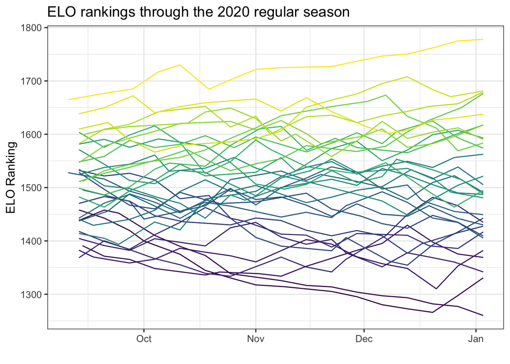

```r
elo = read.csv("https://projects.fivethirtyeight.com/nfl-api/nfl_elo.csv") %>%
  filter(season %in% c("2020")) %>%
  select(date, team1, team2, elo1_pre, elo2_pre) %>%
  tidyr::pivot_longer(cols = c("team1", "team2"), names_to = c("team_order"), values_to = ("team")) %>%
  mutate(elo = case_when(
    team_order == "team1" ~ elo1_pre,
    team_order == "team2" ~ elo2_pre),
    date = as.Date(date)) %>%
  select(date, team, elo) %>%
  mutate(team = reorder(team, elo)) %>%
  filter(date < as.Date("01-09-2021", "%m-%d-%Y"))

ggplot(elo, aes(x = date, y = elo, color = team)) +
  geom_line() +
  scale_color_viridis_d() +
  labs(title = "ELO rankings through the 2020 regular season",
       x = "",
       y = "ELO Ranking") +
  theme_bw(12) +
  theme(legend.position="none")
```

### Historical ELO performance

We want to make sure ELO rankings are creditable to use for our game predictions. If the probabilities of winning each game derived from ELO are creditable, then we would expect games with a 80% probability to be won 80% of the time. We can verify this using the historical ELO data dating back to 1950.

If the ELO rankings are a good indicator of the game outcome, we can expect to see a 45 degree line between ELO projected game outcomes and the actual observed outcomes.

```r
data = read.csv("https://projects.fivethirtyeight.com/nfl-api/nfl_elo.csv") %>%
  mutate(loser_score = ifelse(qbelo_prob1 > qbelo_prob2, score2, score1),
         winner_score = ifelse(qbelo_prob1 > qbelo_prob2, score1, score2),
         p_win_winner = ifelse(qbelo_prob1 > qbelo_prob2, qbelo_prob1, qbelo_prob2),
         win = as.numeric(winner_score > loser_score),
         win_bucket = round(p_win_winner, 2)) %>%
  filter(!is.na(winner_score)) %>%
  group_by(win_bucket) %>%
  summarise(p = mean(win)) %>%
  ggplot(aes(x = win_bucket, y = p)) +
  geom_point() +
  geom_smooth(alpha = 0.7, linetype = "dashed", se = F, method = "loess", formula = "y ~ x") +
  geom_abline(slope = 1) +
  annotate("text", x = 0.5, y = 0.49, label = "y = x", hjust = 0) +
  annotate("text", x = 0.5, y = 0.6, label = "Line of \nbest fit", hjust = 0, color = "blue") +
  labs(title = "The historical outcome observation lines up well with the projected outcomes",
       x = "Forecasted win rate",
       y = "Observed win rate") +
  theme_bw(12)
```

[output not shown]

```r
# Helper Functions ----
read_data = function(path, past_picks, all_weeks = FALSE){
  dt = data.table::fread(path)
  week1 <- as.Date("2021-09-09")

  # calculate week, get proj loser and prob of loss.

  dt[, loser:=ifelse(qbelo_prob1 > qbelo_prob2, team2, team1)]
  dt[, winner:=ifelse(qbelo_prob1 > qbelo_prob2, team1, team2)]
  dt[, p_win:=ifelse(qbelo_prob1 > qbelo_prob2, qbelo_prob2, qbelo_prob1)]
  dt[, p_win_winner:=ifelse(qbelo_prob1 > qbelo_prob2, qbelo_prob1, qbelo_prob2)]
  dt[, week:=floor(as.numeric(difftime(date, week1, units="days")) / 7) + 1]
  dt[, loser_score:=ifelse(qbelo_prob1 > qbelo_prob2, score2, score1)]
  dt[, winner_score:=ifelse(qbelo_prob1 > qbelo_prob2, score1, score2)]
  dt = dt[, upset:=ifelse(loser_score > winner_score, TRUE, FALSE)]

  dt = dt[, .(week, loser, winner, p_win, p_win_winner, upset)]

  return(dt)
}
```

## 2021 NFL Season Data

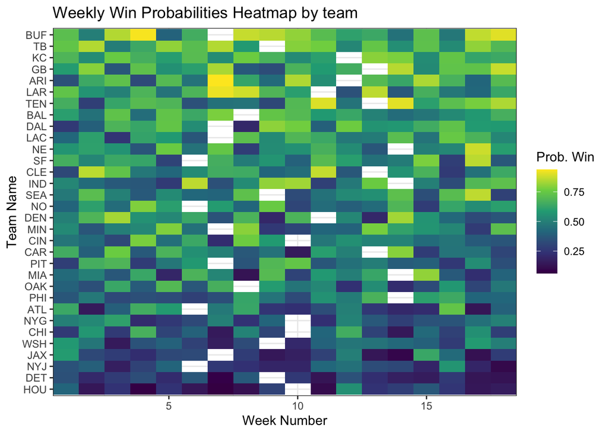

```r
fivethirtyeight = "https://projects.fivethirtyeight.com/nfl-api/nfl_elo_latest.csv"
plot_data = read_data(fivethirtyeight, all_weeks = TRUE)

plot_data %>%
  tidyr::pivot_longer(cols = c("loser", "winner"), values_to = "team") %>%
  mutate(p = ifelse(name == "loser", p_win, p_win_winner)) %>%
  select(-c("p_win", "p_win_winner")) %>%
  group_by(team) %>%
  mutate(win_avg = mean(p)) %>%
  ungroup() %>%
  mutate(team = reorder(team, win_avg)) %>% # reorder teams by avg win
  ggplot(aes(week, team, fill=p)) +
  geom_tile() +
  scale_fill_viridis_c("Prob. Win") +
  theme_bw() +
  labs(title = "Weekly Win Probabilities Heatmap by team",
       x = "Week Number",
       y = "Team Name") +
  scale_x_continuous(expand = c(0, 0))
```

## Determining the optimal pick profile

My approach for the contest was to pick teams based on their opportunity cost of not being selected, or in other words, the percentage differential towards the next best team to pick in a given week. Additionally, since lasting week to week is the most important aspect of the losers pool, I discount the opportunity cost so that future weeks are less important than upcoming weeks.

I also compare the results from my opportunity cost algorithm against a naive algorithm that picks the lowest probability team to win each week.

One specific rule in the Losers Pool, is that players are allowed to reenter into the pool if they are eliminated in Weeks 1 or 2. For this reason, my optimization begins in Week 3, and picks made in Weeks 1 and 2 are the next best teams that are remaining for those weeks after the algorithms are completed.

It is also worth noting, losers pools do not last the entire season. Consider the case of picking a game where a team has a 15% chance of winning, there is roughly a 50% chance of lasting past Week 4, a 20% chance of lasting until Week 10, and a mere 5% chance of lasting until Week 18. Therefore, it would be very costly to earlier weeks to make pick projections out to the 18th week. Instead, I chose to run my algorithms out to Week 10. It also just happens to be that the winner of the 2020 NFL Losers pool was determined in Week 10.

In the sections below, I describe three different algorithms to determining the set of team-week picks to optimize the likelihood of lasting in the losers pool. The three algorithms are:

1. Taking the best pick per week with no foresight
2. Making picks based on minimizing the opportunity cost of each selected team
3. Minimizing the sum of win probabilities with brute force

### Naive Approach - Picking weekly without foresight

We can use a naive algorithm that has no foresight into future periods to compare against the opportunity cost model. Picking the lowest probability team week by week will front-load the best teams and will most likely run into sub optimal picks in later weeks.

The Lowest Pick per Week algorithm begins in Week 3, picks the team with the lowest win probability, then removes that team from being picked in future weeks.

### Oppertunity Cost Model:

The benefit of this algorithm comes with its forward-looking nature. The model determines each weekly pick based on the delta between the best pick that week and the win probability of the next best team. This approach allows for the model to pick teams when they are the most valuable, rather than making the best pick to move on to the next week.

The Opportunity Cost algorithm computes the difference between the best and second best pick for each week, then picks the team with the largest opportunity cost across all weeks in the data set. Then, the selected team and week are discarded from the candidate weeks and team, and the algorithm repeats. Additionally, the algorithm discounts future weeks by a parameter $\beta = 0.8$ that way more weight is placed on upcoming weeks.

Compared to the naive approach, this model preforms worse in early weeks, however out preforms the naive approach the longer the season goes on as the model is trading off early performance for sustained performance.

### Brute Force Model

The Brute Force Model strategically works through all possible combinations of picking the lowest team per week by changing the order of weeks that are selected. Since the algorithms optimize over weeks 3 to 10, there are $8! = 40,320$ possible permutations of orders to consider each weekly pick. By running through all the possible combinations of week orders to make the lowest team pick, we are able to see the cumulative probability of each team losing their game, and then pick the team profile that has the greatest probability of lasting all 10 weeks.

While this model gets at the optimal pick across each week, it struggles with scaling as each additional week increases the number of checks is represented by $N!$.

```r
# Picking functions ----
join_picks <- function(past_weeks, past_picks){
  picks <- setDT(data.frame(week = past_weeks, loser = past_picks))
  picks <- merge(picks, dt, on = week)
  picks <- picks[, .(week, loser, p_win)]

  return(picks)
}

by_oc <- function(dt, past_picks, past_weeks, start_week = 3, total_weeks = 10, beta = 1){

  for(i in start_week:total_weeks){

    pick <- dt[week %in% c(start_week:total_weeks)]
    pick <- pick[!week %in% past_weeks & !loser %in% past_picks, ]
    pick <- pick[order(week, p_win)]
    pick[, oc:= shift(p_win, 1, type="lead") - p_win, by = week]
    pick[, oc:= oc * beta^(week - start_week)]
    pick <- pick[, .SD[1], week]
    pick <- pick[order(-oc)]
    pick <- pick[, .SD[1]]

    past_weeks <- append(past_weeks, pick$week)
    past_picks <- append(past_picks, pick$loser)

  }

  picks <- join_picks(past_weeks, past_picks)

  return(picks)
}

by_week <- function(dt, past_picks, past_weeks, start_week = 3, total_weeks = 10, beta = 1){
  # loop through filling in each week
  for(i in start_week:total_weeks){
    pick <- dt[!loser %in% past_picks & week == i]
    pick[, value:= p_win * beta^(week - start_week)]
    pick <- pick[order(week, value)]
    pick <- pick[, .SD[1]]

    past_weeks <- append(past_weeks, pick$week)
    past_picks <- append(past_picks, pick$loser)

  }

  picks <- join_picks(past_weeks, past_picks)

  return(picks)
}

cumprob <- function(picks, inc_weeks = FALSE){
  p <- purrr::accumulate((1-picks$p_win), function(x, y)  x * y)
  weeks <- picks$Week
  if(inc_weeks){ out <- data.frame(p, weeks) }
  else { out <- data.frame(p) }

  out
}

path = "https://projects.fivethirtyeight.com/nfl-api/nfl_elo_latest.csv"
df = read_data(path, all_weeks = TRUE)
df = tidyr::pivot_longer(df, cols = c("loser", "winner"), names_to = c("favourite"), values_to = ("team"))
df = mutate(df, p = case_when(
  favourite == "loser" ~ p_win,
  favourite == "winner" ~ p_win_winner)) %>%
  select(week, team, p) %>%
  filter(week %in% 1:10)

week_combos = permn(3:8) # 8! or 40320 combinations to consider.
target = 0

for(order in week_combos){
  week_list = c()
  team_list = c()
  score = 1
  for(i in order){
    tmp = setDT(df)[!team %in% team_list & week == i, ]
    tmp = tmp[order(p), .SD[1]] # take lowest pick per week

    team_list = append(team_list, tmp$team)
    week_list = append(week_list, tmp$week)
    score = score * (1 - tmp$p)
  }
  if(score > target){
    target = score
    picks = data.frame(week = week_list, team = team_list)
  }
}

other_weeks = data.frame(week = c(1, 2, 9, 10), team = c("CHI", "TEN", "JAX", "CAR"))
brute_search = rbind(picks, other_weeks)
brute_search = merge(brute_search, df, on = .(week, teams)) # add prob back in
```

### Comparing across models

Lets test out the performance of each algorithm. A couple of useful metrics to use are the average win likelihood across all weeks - note these statistics do not include Weeks 1 and 2 which were not included in the model - as well as the cumulative probabilities of reaching a given week. We can see that with this set of data, the Brute Force model and Opportunity Cost model are nearly identical in terms of their average week by week probabilities. The Brute Force model does have a slightly lower standard deviation.

Optimal Picks per Week

| Week | Oppertunity Cost Team | Oppertunity Cost ProbWin | Lowest Per Week Team | Lowest Per Week ProbWin | Brute Force Team | Brute Force ProbWin |
| --- | --- | --- | --- | --- | --- | --- |
| 1 | DAL | 0.2639 | DAL | 0.2639 | CHI | 0.2660 |
| 2 | TEN | 0.2863 | TEN | 0.2863 | TEN | 0.2863 |
| 3 | WSH | 0.1526 | WSH | 0.1526 | WSH | 0.1526 |
| 4 | NYG | 0.2137 | HOU | 0.0675 | NYG | 0.2137 |
| 5 | IND | 0.2651 | MIA | 0.1941 | MIA | 0.1941 |
| 6 | HOU | 0.1408 | PHI | 0.2905 | HOU | 0.1408 |
| 7 | DET | 0.0826 | DET | 0.0826 | DET | 0.0826 |
| 8 | MIA | 0.1289 | NYJ | 0.2351 | DAL | 0.2008 |
| 9 | JAX | 0.1450 | JAX | 0.1450 | JAX | 0.1450 |
| 10 | CAR | 0.1548 | CAR | 0.1548 | CAR | 0.1548 |
| Mean |  | 0.1604 |  | 0.1653 |  | 0.1606 |
| SD |  | 0.0555 |  | 0.0741 |  | 0.0420 |

When looking at the likelihood of reaching a given week, we can see that all three models preform pretty similar to each-other, however the Opportunity Cost and Brute Force models eventually pass the By Week model. If we stretch the weeks in the analysis, I would expect to see even better performance from the Opportunity Cost model.

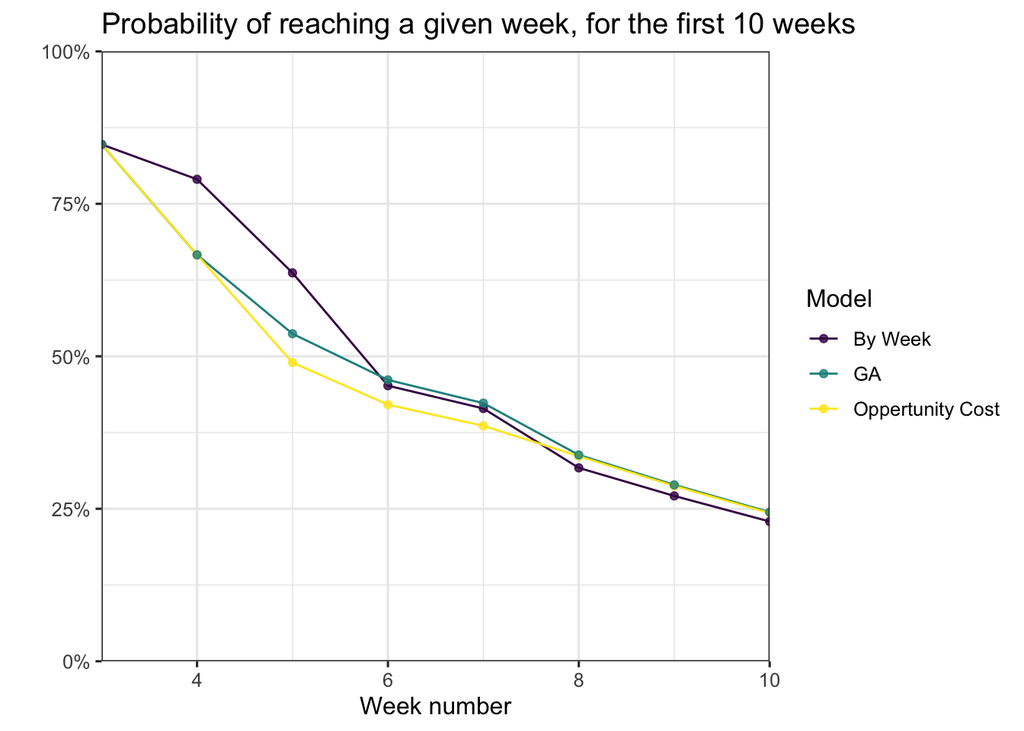

```r
# Probability of reaching a given week ----
models = list(pick[3:10, ], naive[3:10, ], brute_search[3:10, ])
models = lapply(models, cumprob) %>%
  bind_cols()
models$week = 3:10
names(models) = c("Oppertunity Cost", "By Week", "GA", "Week")
models %>%
  tidyr::pivot_longer(cols = -Week, names_to = "Model", values_to = "p") %>%
  ggplot(aes(x = Week, y = p, color = Model)) +
  geom_line() +
  geom_point(alpha = 0.8) +
  scale_x_continuous(expand = c(0, 0), limits = c(3, 10)) +
  scale_y_continuous(expand = c(0, 0), limits = c(0, 1), labels = percent) +
  scale_color_viridis_d() +
  labs(title = "Probability of reaching a given week, for the first 10 weeks",
       x = "Week number",
       y = "") +
  theme_bw(12)
```

Lastly, we can look at the differences in week-by-week selections across the models. The foresight taken by both the Brute Force and Opportunity Cost models come to light in the below plot, specifically in Week 4 where only the Lowest per Week model takes Houston, while the Brute Force and Opportunity Cost models instead wait until week 6 to take Houston and avoid being stuck with a risky Philadelphia.

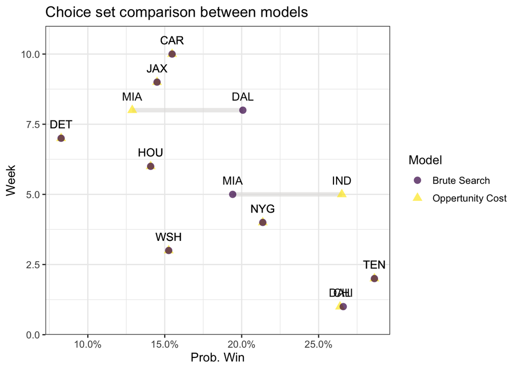

```r
# Plot choice set of each model ----
pick$approach = "Oppertunity Cost"
naive$approach = "Lowest per Week"
brute_search$approach = "Brute Search"
compare = rbind(pick, brute_search)

ggplot(compare, aes(x = week, y = p_win, color = approach, shape = approach, label = loser)) +
  geom_line(aes(group = week), color="#e3e2e1", size = 2, alpha = 0.7) +
  geom_point(size = 3, alpha = 0.7) +
  geom_text(color = "black", nudge_x = 0.5) +
  scale_color_viridis_d() +
  coord_flip() +
  scale_x_continuous(expand = c(0, 0), limits = c(0, 11)) +
  scale_y_continuous(labels = percent) +
  labs(title = "Choice set comparison between models",
       x = "Week",
       y = "Prob. Win",
       color = "Model",
       shape = "Model") +
  theme_bw(12)
```

## Season Results

Armed with the above insight, I tackled the Losers Pool taking insights from both the Opportunity Cost and Brute Search models. Also, a quick disclaimer, the game probabilities update after each week, therefore picks in earlier weeks in hindsight may look less than optimal as the forecasts of future games have changed. With that out of the way, here are the results of the season. We began with 33 players, and each choice set is shown below. Eliminations are shown by the yellow dots.

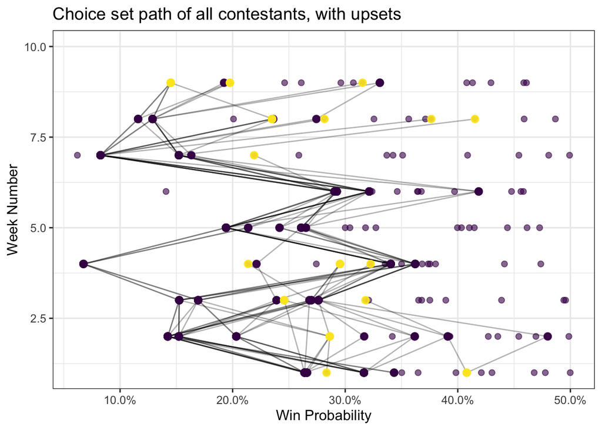

```r
ownership <- "https://docs.google.com/spreadsheets/d/1sajv1HXDqzjG2bXwx927MTP_TUKRWsjVSvKAwnaWZcs/edit?usp=sharing"
own <- googlesheets4::read_sheet(ownership) %>%
  tidyr::pivot_longer(cols = contains("Week"), names_to = "Week", values_to = "Pick") %>%
  mutate(Week = as.numeric(gsub("Week ", "", Week)),
         OUT = ifelse(Pick == "OUT", TRUE, FALSE),
         Pick = case_when(Pick == "WFT" ~ "WSH",
                          Pick == "LVR" ~ "LAR",
                          Pick == "AZ" ~ "ARI",
                          TRUE ~ Pick)) %>%
  group_by(Player, Week) %>%
  left_join(dt, by = c("Week" = "week", "Pick" = "loser")) %>%
  select("Week", "Pick", "p_win", "Player", "OUT", "upset") %>%
  mutate(p_win = case_when(
    is.na(p_win) ~ 0.5,
    TRUE ~ p_win))


ggplot(subset(plot_data, week < 10), aes(x = week, y = p_win)) +
  geom_point(size = 2, alpha = 0.6, color = "#440154FF") +
  geom_line(data = subset(own, p_win != 0.5), mapping = aes(x = Week, y = p_win, group = Player), alpha = 0.3) +
  geom_point(data = subset(own, p_win != 0.5), mapping = aes(x = Week, y = p_win, color = upset), size = 2, alpha = 0.9, stroke = 1) +
  coord_flip() +
  xlim(1, 10) +
  # annotate("text", x = 1 + 0.05, y = 0, label="forecast \nhistorical", hjust = 0, color = "darkgrey") +
  labs(title = "Choice set path of all contestants, with upsets",
       y = "Win Probability",
       x = "Week Number") +
  theme_bw(12) +
  theme(legend.position="none") +
  scale_color_manual(values=c("#440154FF", "#FDE725FF")) +
  scale_y_continuous(labels = percent)
```

The season only lasted to Week 9, with three players splitting the pot.

Admittedly, I did not follow the above Opportunity Cost Algorithm perfectly. I had two entries, and so chose to offset the picks I was making each week to mitigate some of the risk.

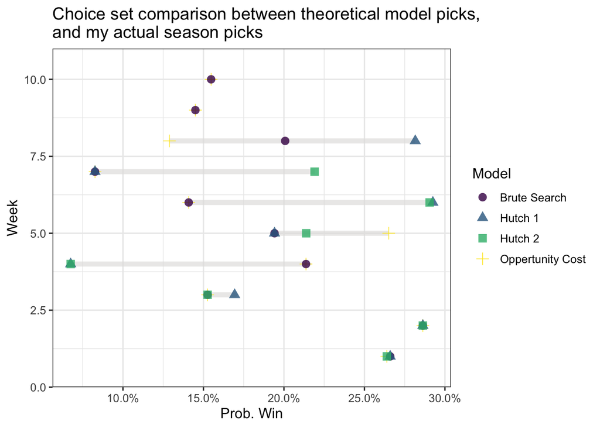

```r
# Plot actual selection ----
jordan_picks = own[grepl("Hutch", own$Player), c("Week", "Pick", "p_win", "Player")]
names(jordan_picks) = names(compare)
compare = rbind(compare, jordan_picks)
compare = compare %>% filter(loser != "OUT")

ggplot(compare, aes(x = week, y = p_win, color = approach, shape = approach, label = loser)) +
  geom_line(aes(group = week), color="#e3e2e1", size = 2, alpha = 0.7) +
  geom_point(size = 3, alpha = 0.8) +
  scale_color_viridis_d() +
  coord_flip() +
  scale_x_continuous(expand = c(0, 0), limits = c(0, 11)) +
  scale_y_continuous(labels = percent) +
  labs(title = "Choice set comparison between theoretical model picks, \nand my actual season picks",
       x = "Week",
       y = "Prob. Win",
       color = "Model",
       shape = "Model") +
  theme_bw(12)
```

If we compare the cumulative probabilities across the above models, and the actual picks I put into practice, we can see that the opportunity cost model ended up with the higher probability by Week 10. The only downside is taking on the increased risk earlier in weeks 4 and 5.

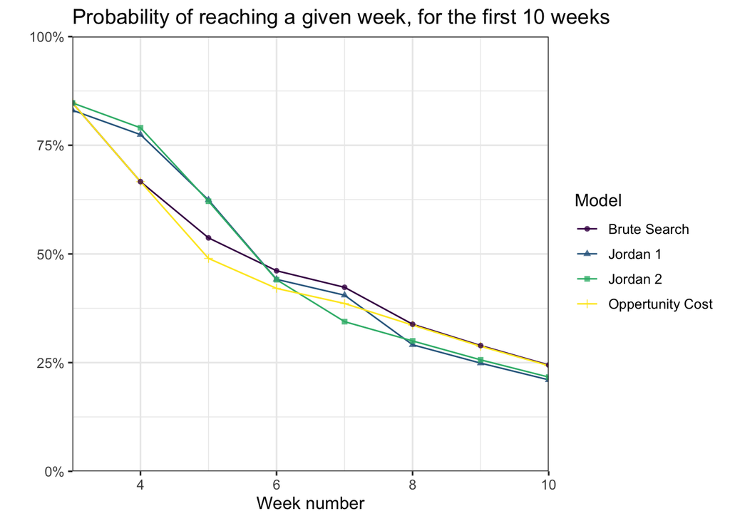

```r
# Plot cumprob ----

# project remaining picks for each set of picks
jordan_1 = jordan_picks[jordan_picks$approach == "Hutch 1", ]
jordan_2 = jordan_picks[jordan_picks$approach == "Hutch 2", ]
jordan_1 = by_oc(dt, past_picks = jordan_1$loser[1:8], past_weeks = 1:8, beta = 1, start_week = 1, total_weeks = 10)
jordan_2 = by_oc(dt, past_picks = jordan_2$loser[1:7], past_weeks = 1:7, beta = 1, start_week = 1, total_weeks = 10)

# add to data set
jordan_1$approach = "Jordan 1"
jordan_2$approach = "Jordan 2"
models = list(pick[3:10, ], brute_search[3:10, ], jordan_1[3:10, ], jordan_2[3:10, ])
models = lapply(models, cumprob) %>%
  bind_cols()
models$week = 3:10
names(models) = c("Oppertunity Cost", "Brute Search", "Jordan 1", "Jordan 2", "Week")
models %>%
  tidyr::pivot_longer(cols = -Week, names_to = "Model", values_to = "p") %>%
  ggplot(aes(x = Week, y = p, color = Model, shape = Model)) +
  geom_line() +
  geom_point(alpha = 0.8) +
  scale_x_continuous(expand = c(0, 0), limits = c(3, 10)) +
  scale_y_continuous(expand = c(0, 0), limits = c(0, 1), labels = percent) +
  scale_color_viridis_d() +
  labs(title = "Probability of reaching a given week, for the first 10 weeks",
       x = "Week number",
       y = "") +
  theme_bw(12)
```

Using the same chart format, what do things look like for all the competitors in the pool? We don’t know the picks that would be made by competitors who’ve lost in earlier weeks, therefore, I will only plot the projected probabilities up until each person lost.

In order to compare my performance with others, I plotted my pick projections in purple. We can see, I was in great shape before losing my second team in Week 7 and top team in Week 8. In fact, My probability of making week 8 was greater than that of a majority of teams making week 6.

Despite not making the final 3 in the pool - the payout positions - my algorithm placed me in a fantastic position to make money in the pool.

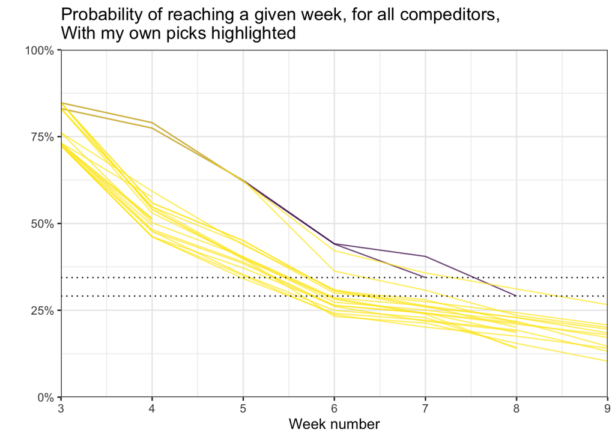

```r
# plot cumulative probabilities
tbl_data = filter(own, Pick != "OUT" & Week > 2) %>%
  group_by(Player) %>%
  mutate(cum_prob = cumprod(1-p_win),
         own = ifelse(Player == "Hutch 1" | Player == "Hutch 2", TRUE, FALSE)) %>%
  ungroup() %>%
  group_by(Player) %>%
  mutate(win_avg = max(Week) + (min(cum_prob))) %>%
  ungroup() %>%
  mutate(Player = reorder(Player, win_avg))

ggplot(tbl_data, aes(x = Week, y = cum_prob, group = Player, color = own)) +
  geom_line(alpha = 0.7) +
  scale_x_continuous(expand = c(0, 0), limits = c(3, 9)) +
  scale_y_continuous(expand = c(0, 0), limits = c(0, 1), labels = percent) +
  scale_color_viridis_d(direction = -1) +
  geom_hline(yintercept = min(subset(tbl_data, Player == "Hutch 1")$cum_prob), linetype = "dotted") +
  geom_hline(yintercept = min(subset(tbl_data, Player == "Hutch 2")$cum_prob), linetype = "dotted") +
  labs(title = "Probability of reaching a given week, for all compeditors, \nWith my own picks highlighted",
       x = "Week number",
       y = "") +
    theme_bw(12) +
    theme(legend.position = "none")
```

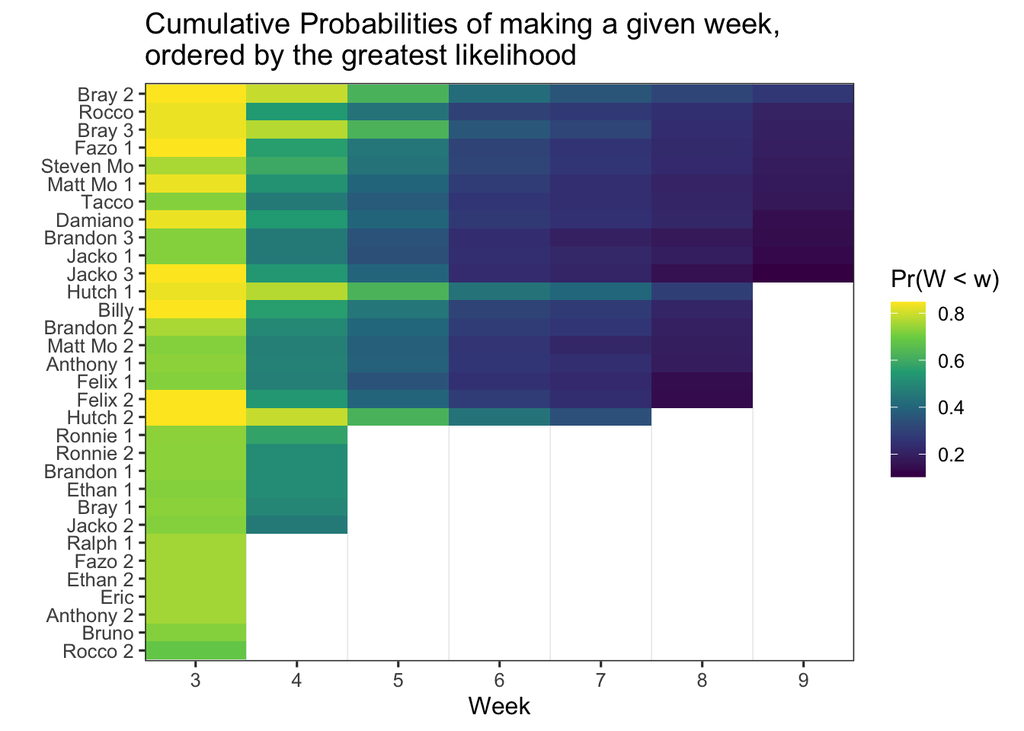

```r
# plot heatmap of cum prob
ggplot(tbl_data, aes(y = Player, x = Week, fill = cum_prob)) +
  geom_tile() +
  scale_x_continuous(expand = c(0, 0), breaks = 3:9) +
  scale_fill_viridis_c(direction = 1) +
  labs(title = "Cumulative Probabilities of making a given week, \nordered by the greatest likelihood",
       x = "Week",
       y = "",
       fill = "Pr(W < w)") +
  theme_bw(12) +
  theme(panel.grid.major = element_blank())
```